# TCGA data & packages primer

NGSprint Data Visualization in Bioinformatics

[Kasia Kedzierska](https://kasia.codes/)

Created on 06 Sep, 2021 Last compiled on 10 Sep, 2021

# Setup

Run if you don’t have the packages installed.

```r
# a helper abbreviation
`%not in%` <- Negate(`%in%`)

if (!requireNamespace("BiocManager", quietly = TRUE)) {
    install.packages("BiocManager")
}

needed_packages <-
  c("recount3", "maftools", "DESeq2", "TCGAbiolinks")

for (pkg in needed_packages) {
  if (pkg %not in% rownames(installed.packages())) {
    print(paste("Trying to install", pkg))
    BiocManager::install(pkg)
    if ((pkg %not in% rownames(installed.packages()))) {
      msg <- paste("ERROR: Unsuccessful!", pkg, "not installed!",
                   "Check the log and try installing the package manually.")
      stop(msg)
    }
  }
  library(pkg, character.only = TRUE)
  ifelse(pkg %in% loadedNamespaces(),
         print(paste("Successful!", pkg, "loaded.")),
         print(paste("ERROR: Unsuccessful!", pkg,
                     "not loaded. Check error msg.")))
}
```

Load all the packages and define functions.

```r
library(recount3)
library(TCGAbiolinks)
```

# Gene expression

## Preparing the data

Using `recount3` we download the data for a Lower Grade Glioma (**LGG**). In order to read more about the package and explore more of its function, refer to the [manual](http://research.libd.org/recount3/index.html) and [quick guide](http://research.libd.org/recount3/articles/recount3-quickstart.html).

```r
data_dir <- "data"

rse_gene <-
  create_rse(
    subset(
      available_projects(),
      project == "LGG" & project_type == "data_sources"
    )
  )
```

Now, let’s explore what are we looking at?

```r
assayNames(rse_gene)
```

```
[1] "raw_counts"
```

We need to scale the reads to be able to use them in `DESeq2` processing.

```r
assay(rse_gene, "counts") <-
  transform_counts(rse_gene)
```

The attached colData contains a lot of information that we can use on top of the expression data.

|  | sample_id | rail_id | external_id | study | tcga.tcga_barcode | tcga.gdc_file_id | tcga.gdc_cases.project.name | tcga.gdc_cases.project.released | tcga.gdc_cases.project.state | tcga.gdc_cases.project.primary_site | tcga.gdc_cases.project.project_id | tcga.cgc_sample_sample_type | tcga.gdc_cases.case_id | tcga.gdc_updated_datetime | tcga.gdc_file_name | tcga.gdc_submitter_id | tcga.gdc_file_size | tcga.gdc_access | tcga.gdc_platform | tcga.gdc_state | tcga.gdc_type | tcga.gdc_file_state | tcga.gdc_experimental_strategy | tcga.gdc_data_type | tcga.gdc_md5sum | tcga.gdc_data_format | tcga.gdc_data_category | tcga.gdc_center.code | tcga.gdc_center.name | … |
| --- | --- | --- | --- | --- | --- | --- | --- | --- | --- | --- | --- | --- | --- | --- | --- | --- | --- | --- | --- | --- | --- | --- | --- | --- | --- | --- | --- | --- | --- | --- |
| 1 | f56466dc-3c0f-48be-8a72-cedeaef52f00 | 106631 | f56466dc-3c0f-48be-8a72-cedeaef52f00 | LGG | TCGA-TQ-A7RK-02A-11R-A36H-07 | f56466dc-3c0f-48be-8a72-cedeaef52f00 | Brain Lower Grade Glioma | TRUE | legacy | Brain | TCGA-LGG | Recurrent Tumor | 2f8c789e-bbd8-4753-a48b-6894c21162f8 | 2016-09-30T00:06:15.511842-05:00 | UNCID_2479142.707a0918-ae88-4c3c-9a94-e9fad5cdbc7b.140325_UNC15-SN850_0358_AC3LP7ACXX_6_CCGTCC.tar.gz | 0e2390a6-d7f8-4384-af5b-74c301f606e0 | 6260692493 | controlled | Illumina HiSeq | live | file | NA | RNA-Seq | Unaligned reads | 96f22a2d460ee036c8410d1041fb65dd | TARGZ | Raw sequencing data | 7 | University of North Carolina | … |
| 2 | f35f85a8-b3cd-4116-990f-94b2e432f902 | 106646 | f35f85a8-b3cd-4116-990f-94b2e432f902 | LGG | TCGA-P5-A5EW-01A-11R-A27Q-07 | f35f85a8-b3cd-4116-990f-94b2e432f902 | Brain Lower Grade Glioma | TRUE | legacy | Brain | TCGA-LGG | Primary Tumor | 6d02e00c-56a5-4433-9930-f036e2aa39aa | 2016-08-09T13:15:10.996741-05:00 | UNCID_2176822.ab00d03b-2579-491b-a23a-7ec63d0852ff.130412_UNC10-SN254_0452_BC22WAACXX_8_GGCTAC.tar.gz | 6141f62c-f225-4db6-aa3e-47418425c487 | 5782422239 | controlled | Illumina HiSeq | live | file | NA | RNA-Seq | Unaligned reads | 1de2c4de0b010d115541c3a574b0732b | TARGZ | Raw sequencing data | 7 | University of North Carolina | … |
| 3 | b11ff528-846e-4e40-9e32-e5820ecb5504 | 106663 | b11ff528-846e-4e40-9e32-e5820ecb5504 | LGG | TCGA-DU-A6S2-01A-21R-A32Q-07 | b11ff528-846e-4e40-9e32-e5820ecb5504 | Brain Lower Grade Glioma | TRUE | legacy | Brain | TCGA-LGG | Primary Tumor | baaddd76-277f-4c90-9cc2-0fece30c9735 | 2016-08-26T04:43:17.555681-05:00 | UNCID_2318940.4c7061f2-ff48-4079-97b6-7ae3c7c0f905.131112_UNC12-SN629_0335_BC34FKACXX_3_CAGATC.tar.gz | e67bcf5c-7f5b-4951-a6fe-32fc3a52bef4 | 6149423270 | controlled | Illumina HiSeq | live | file | NA | RNA-Seq | Unaligned reads | 8cbbf34a8c217a2e699f11d47939a576 | TARGZ | Raw sequencing data | 7 | University of North Carolina | … |

For plotting, we will use the variance stabilizing transformation (**vst**) normalized counts (as it is quicker than **rlog**). To read more about normalization, please read [Data transformations and visualization](https://www.bioconductor.org/packages/devel/bioc/vignettes/DESeq2/inst/doc/DESeq2.html#data-transformations-and-visualization) section of RNA-seq data anlysis guide from Bioconductor.

```r
normalized_counts <-
  vst(assays(rse_gene)$counts)
```

```
partial argument match of 'length' to 'length.out'
```

## First visualization

Let’s see the expression of top variable genes.

```r
row_var <-
  rowVars(normalized_counts)
```

Now, let’s generate the first heatmap with top 0.5 % of highly variable genes.

```r
ht <-
  Heatmap(scale2(normalized_counts[row_var > quantile(row_var, 0.995),]),
        show_row_names = FALSE, show_column_names = FALSE,
        clustering_distance_rows = "pearson", name = "gene expression",
        col = viridis::viridis(100))
```

```
partial argument match of 'length' to 'length.out'
```

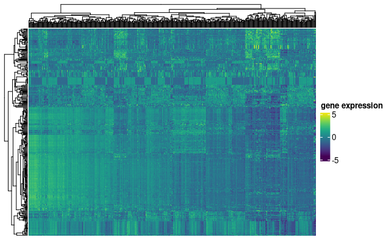

```r
ht
```

Do we have only single samples in the data?

| patient_id | count | sample_type |
| --- | --- | --- |
| TCGA-DH-A669 | 2 | Primary Tumor, Recurrent Tumor |
| TCGA-DU-5870 | 2 | Primary Tumor, Recurrent Tumor |
| TCGA-DU-5872 | 2 | Primary Tumor, Recurrent Tumor |
| TCGA-DU-6397 | 2 | Primary Tumor, Recurrent Tumor |
| TCGA-DU-6404 | 3 | Primary Tumor, Recurrent Tumor |
| TCGA-DU-6407 | 3 | Primary Tumor, Recurrent Tumor |
| TCGA-DU-7304 | 2 | Primary Tumor, Recurrent Tumor |
| TCGA-FG-5963 | 2 | Primary Tumor, Recurrent Tumor |
| TCGA-FG-5965 | 3 | Primary Tumor, Recurrent Tumor |
| TCGA-FG-A4MT | 2 | Primary Tumor, Recurrent Tumor |

[output cut: 4 more lines]

Let’s add the sample type annotation to the heatmap.

```r
ha <-
  sample_sheet %>%
  select(sample_id, `Sample type` = tcga.cgc_sample_sample_type) %>%
  column_to_rownames("sample_id") %>%
  HeatmapAnnotation(df = .)

ht2 <-
  Heatmap(scale2(normalized_counts[row_var > quantile(row_var, 0.995),]),
        show_row_names = FALSE, show_column_names = FALSE,
        clustering_distance_rows = "pearson", name = "gene expression",
        col = viridis::viridis(100), top_annotation = ha)
```

```
partial argument match of 'length' to 'length.out'
```

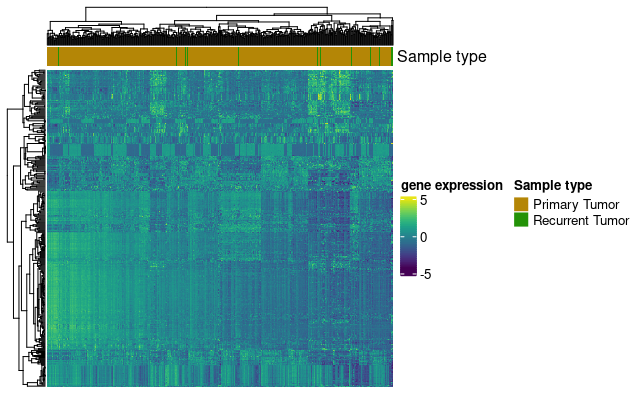

```r
ht2
```

We don’t see any separate clusters between Primary and Recurrent Tumors (albeit we only are looking at 0.5% of most variable genes and there is quite significant class inbalance). Depend on what we would want to show next, we might want to remove those reccurent samples.

# Somatic mutations

We will now use the great `TCGAbiolinks` package that help accessing the vast data source of TCGA. Read more abou this great package [here](https://www.bioconductor.org/packages/release/bioc/vignettes/TCGAbiolinks/inst/doc/index.html).

```r
maf <-
  GDCquery_Maf("LGG", pipelines = "mutect2") %>%
  read.maf()
```

First thing we can do is the mutation specific summary - what kind of mutations do we have in a sample? For that we will use functions from another great package - `maftools` a dedicated package to visualize maf data. You can see what brilliant things the package does and what things you can easily investigate [here](https://bioconductor.org/packages/release/bioc/vignettes/maftools/inst/doc/maftools.html).

```
partial argument match of 'id' to 'id.vars'
```

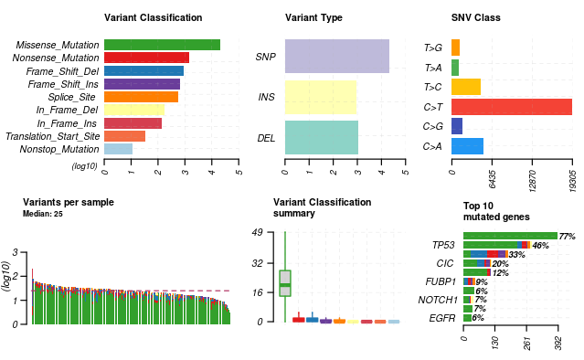

```r
plotmafSummary(maf = maf, rmOutlier = TRUE,
               addStat = 'median', dashboard = TRUE, log_scale = TRUE)
```

First thing we see is that this cancer type does not have many mutations. We can compare it with other TCGA cancer types.

```
Removed 1 samples with zero mutations.Performing pairwise t-test for differences in mutation burden..
```

| Cohort | Cohort_Size | Median_Mutations | Median_Mutations_log10 |
| --- | --- | --- | --- |
| LAML | 137 | 9.0 | 0.9542 |
| PCPG | 183 | 9.0 | 0.9542 |
| THCA | 499 | 10.0 | 1.0000 |
| UVM | 80 | 11.5 | 1.0607 |
| TGCT | 133 | 13.0 | 1.1139 |
| THYM | 123 | 14.0 | 1.1461 |
| KICH | 66 | 19.5 | 1.2900 |
| ACC | 92 | 25.5 | 1.4065 |
| LGG | 1031 | 26.0 | 1.4150 |
| MESO | 82 | 27.0 | 1.4314 |

[output cut: 23 more lines]

| Tumor_Sample_Barcode | total | cohort |
| --- | --- | --- |
| TCGA-AB-2808-03B-01W-0728-08 | 741 | LAML |
| TCGA-AB-2828-03B-01W-0728-08 | 718 | LAML |
| TCGA-AB-2826-03B-01W-0728-08 | 616 | LAML |
| TCGA-AB-2806-03B-01W-0728-08 | 491 | LAML |
| TCGA-AB-2833-03B-01W-0728-08 | 445 | LAML |
| TCGA-AB-2854-03B-01W-0728-08 | 285 | LAML |
| TCGA-AB-2807-03B-01W-0728-08 | 232 | LAML |
| TCGA-AB-2868-03B-01W-0728-08 | 66 | LAML |
| TCGA-AB-2805-03B-01W-0728-08 | 45 | LAML |
| TCGA-AB-2804-03B-01W-0728-08 | 38 | LAML |

[output cut: 90 more lines]

| Cohort1 | Cohort2 | Pval |
| --- | --- | --- |
| UCEC | LGG | 0.00000000000000000000000000000000000000000000000000000000000000000000000000000000000000000000000000000000001297 |
| UCEC | BRCA | 0.00000000000000000000000000000000000000000000000000000000000000000000000000000000000000000000000000017882631370 |
| UCEC | THCA | 0.00000000000000000000000000000000000000000000000000000000000000000000000000000000000014100818813190199440462482 |
| UCEC | PRAD | 0.00000000000000000000000000000000000000000000000000000000000000000000000000000001988100449995302078593958615200 |
| UCEC | KIRC | 0.00000000000000000000000000000000000000000000000000000000000000000035248564596741265295523637147583701396275843 |
| UCEC | OV | 0.00000000000000000000000000000000000000000000000000000000000000000035248564596741265295523637147583701396275843 |
| UCEC | HNSC | 0.00000000000000000000000000000000000000000000000000000000000000064987648613284073159536097212565530177231489648 |
| UCEC | GBM | 0.00000000000000000000000000000000000000000000000000000000000003673119710771826172894270570598914775621371375203 |
| UCEC | LIHC | 0.00000000000000000000000000000000000000000000000000000000000097105858953350754384031297183148919198135652309582 |
| UCEC | KIRP | 0.00000000000000000000000000000000000000000000000000000163746213790891087762293124584621641215779287002605165416 |

[output cut: 90 more lines]

```
NA
```

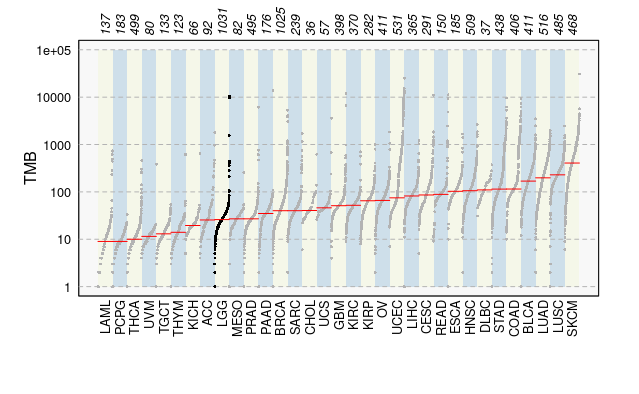

```r
tcgaCompare(maf = maf, cohortName = "LGG")
```

We can see that LGG is one of the less mutated cancers.

Now, we can look at the top mutated genes.

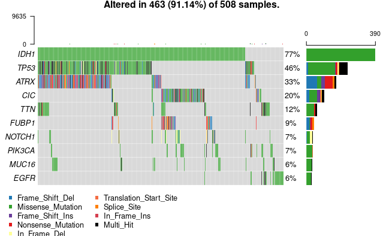

*IDH1* is by far the most mutated gene - are mutations in that gene in one hotspot or distributed? Let’s visualize the mutations in this gene.

```
Assuming protein change information are stored under column HGVSp_Short. Use argument AACol to override if necessary.
```

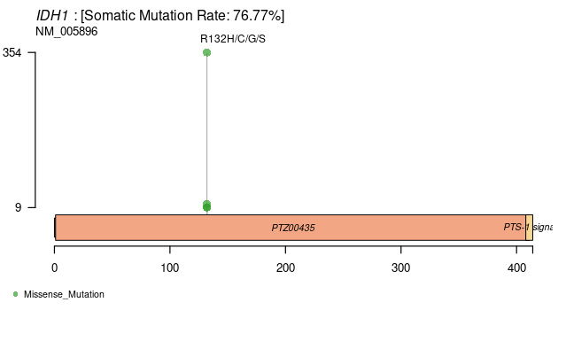

```r
lollipopPlot(maf, "IDH1", labelPos = 'all')
```

Clearly the R132 position is a hotspot, mutated in more than 3/4 of the samples!

The case is not so clear with TP53.

```
Assuming protein change information are stored under column HGVSp_Short. Use argument AACol to override if necessary.
8 transcripts available. Use arguments refSeqID or proteinID to manually specify tx name.
```

| HGNC | refseq.ID | protein.ID | aa.length |
| --- | --- | --- | --- |
| TP53 | NM_000546 | NP_000537 | 393 |
| TP53 | NM_001126112 | NP_001119584 | 393 |
| TP53 | NM_001126118 | NP_001119590 | 354 |
| TP53 | NM_001126115 | NP_001119587 | 261 |
| TP53 | NM_001126113 | NP_001119585 | 346 |
| TP53 | NM_001126117 | NP_001119589 | 214 |
| TP53 | NM_001126114 | NP_001119586 | 341 |
| TP53 | NM_001126116 | NP_001119588 | 209 |

```
Using longer transcript NM_000546 for now.
```

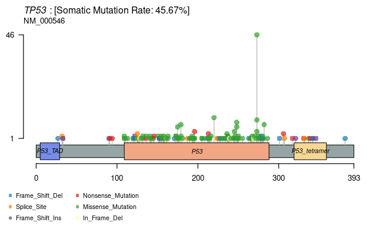

```r
lollipopPlot(maf, "TP53")
```

And neither it is with *ATRX*. Interestingly, this gene is enriched for Frameshift and Nonsense mutations.

```
Assuming protein change information are stored under column HGVSp_Short. Use argument AACol to override if necessary.
2 transcripts available. Use arguments refSeqID or proteinID to manually specify tx name.
```

| HGNC | refseq.ID | protein.ID | aa.length |
| --- | --- | --- | --- |
| ATRX | NM_138270 | NP_612114 | 2454 |
| ATRX | NM_000489 | NP_000480 | 2492 |

```
Using longer transcript NM_000489 for now.
```

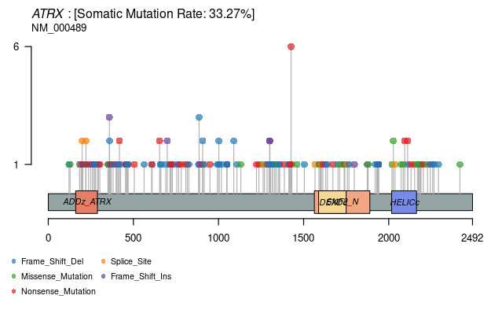

```r
lollipopPlot(maf, "ATRX")
```

We can also look at the cooccurences and mutual exclusivity - which genes are frequently mutated together? Which aren’t?

| gene1 | gene2 | pValue | oddsRatio | 00 | 11 | 01 | 10 | Event | pair | event_ratio |
| --- | --- | --- | --- | --- | --- | --- | --- | --- | --- | --- |
| TP53 | ATRX | 0.0000000000000000000000000000000000000000002078 | 21.243069 | 255 | 148 | 21 | 84 | Co_Occurence | ATRX, TP53 | 148/105 |
| CIC | TP53 | 0.0000000000000000000000431958731897277595533509 | 0.042167 | 181 | 5 | 227 | 95 | Mutually_Exclusive | CIC, TP53 | 5/322 |
| EGFR | IDH1 | 0.0000000000000000001027780088878072880480609365 | 0.007622 | 88 | 1 | 389 | 30 | Mutually_Exclusive | EGFR, IDH1 | 1/419 |
| FUBP1 | CIC | 0.0000000000000001814055950191149159087165490813 | 16.109836 | 396 | 33 | 67 | 12 | Co_Occurence | CIC, FUBP1 | 33/79 |
| TP53 | IDH1 | 0.0000000000000057230594638057533864974857772451 | 6.731154 | 100 | 214 | 176 | 18 | Co_Occurence | IDH1, TP53 | 214/194 |
| CIC | ATRX | 0.0000000000000090493051317022770358256007897093 | 0.061568 | 243 | 4 | 165 | 96 | Mutually_Exclusive | ATRX, CIC | 4/261 |
| IDH2 | IDH1 | 0.0000000000000111270833986301891195623855075995 | 0.000000 | 97 | 0 | 390 | 21 | Mutually_Exclusive | IDH1, IDH2 | 0/411 |
| ATRX | IDH1 | 0.0000000000979457166137216703010155979980562706 | 5.934545 | 106 | 157 | 233 | 12 | Co_Occurence | ATRX, IDH1 | 157/245 |
| PTEN | IDH1 | 0.0000000039854889423670528957015749156860690006 | 0.068165 | 99 | 5 | 385 | 19 | Mutually_Exclusive | IDH1, PTEN | 5/404 |
| NF1 | IDH1 | 0.0000000811776287027212982915389482239942875452 | 0.116417 | 98 | 9 | 381 | 20 | Mutually_Exclusive | IDH1, NF1 | 9/401 |

[output cut: 90 more lines]

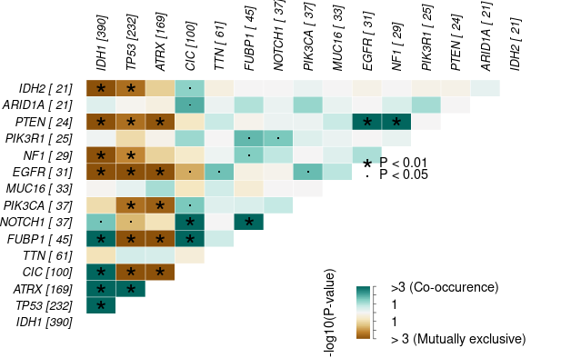

# Clinical data

With the `recount3` data comes clinical information as well. For example, we can check the sex or ethnicity of the patients with `tcga.gdc_cases.demographic.` columns.

| tcga.gdc_cases.demographic.updated_datetime | tcga.gdc_cases.demographic.gender | tcga.gdc_cases.demographic.submitter_id | tcga.gdc_cases.demographic.year_of_birth | tcga.gdc_cases.demographic.race | tcga.gdc_cases.demographic.demographic_id | tcga.gdc_cases.demographic.ethnicity | tcga.gdc_cases.demographic.year_of_death |
| --- | --- | --- | --- | --- | --- | --- | --- |
| 2016-09-02T19:10:27.074552-05:00 | male | TCGA-TQ-A7RK_demographic | 1981 | white | 1ab2adbe-c25b-53a0-9a77-20291290632e | hispanic or latino | NA |
| 2016-09-02T18:54:08.588764-05:00 | female | TCGA-P5-A5EW_demographic | 1992 | white | bb609827-dae8-56f1-8ed6-36fc2ccbf0a2 | not hispanic or latino | NA |
| 2016-09-02T19:09:48.988415-05:00 | female | TCGA-DU-A6S2_demographic | 1976 | black or african american | f89ea10b-8dee-52db-8f20-4ee43741b740 | not hispanic or latino | NA |
| 2016-09-02T19:08:59.918028-05:00 | female | TCGA-HT-7482_demographic | 1987 | white | 174ecf8b-6818-5ffb-ad4b-48ff9b534f1b | not hispanic or latino | NA |
| 2016-09-02T18:56:53.224298-05:00 | male | TCGA-HT-7684_demographic | 1950 | white | a19d13f8-7ba2-5f6c-aae3-9d4acdb9a0f7 | not hispanic or latino | NA |
| 2016-09-02T18:56:47.408416-05:00 | male | TCGA-FG-8188_demographic | 1971 | white | 84a80e11-5c03-5efa-989a-5a4edbdb3a68 | not hispanic or latino | NA |
| 2016-09-02T19:15:17.565615-05:00 | male | TCGA-HT-7873_demographic | 1982 | white | c283588d-b822-57ff-8690-069fa2bec7eb | not hispanic or latino | NA |
| NA | NA | NA | NA | NA | NA | NA | NA |
| 2016-09-02T18:57:45.740903-05:00 | female | TCGA-DB-A64X_demographic | 1956 | white | 8ec3eab2-e672-565c-ac67-5affdcc9ea2a | not hispanic or latino | NA |
| 2016-09-02T19:10:30.497532-05:00 | female | TCGA-TQ-A7RI_demographic | 1975 | white | f4a83eab-cde2-511a-8b7c-84236de6ad83 | hispanic or latino | NA |

[output cut: 90 more lines]

There’s much more data in that dataframe - after all there are almost a thousand columns.

We can also access addiitional data from `TCGAbiolinks`, for example we can see in what subtypes were the samples separated into.

```r
tcga_subtype_data <-
  TCGAquery_subtype(tumor = "lgg")

tcga_subtype_data %>%
  select(ends_with("subtype"))
```

[output not shown]

The dataframe contains much more data, and the function prints out information about the publication the data comes from.

# What next?

You can do much more with those data - firstly, you can draw inspiration from the vignettes of the packages. Secondly, you can see what is interesting to you, what you would want to know? Thirdly, this is already published data and you can always refer to the paper - maybe there are some figures you have an idea to improve?

Few ideas from the top of my head: * improve the heatmap by adding the subtype, sex and other variable annotations. Add the mutation in various top genes as annotations at the bottom; * acces sthe suviaval data and see how they separate based on the subtype; * visualise point mutations on the protein (for example [here](https://michelanglo.sgc.ox.ac.uk/))

For example, in order to add IDH1 annotation, we need to join the information from two dataframes (one that has unique column ids and one that has the information about mutation).

```r
ha_bottom <-
  maf@data %>%
  mutate(patient_id = str_extract(Tumor_Sample_Barcode,
                                  "[^-]{4}-[^-]{2}-[^-]{4}")) %>%
  select(Hugo_Symbol, patient_id) %>%
  filter(Hugo_Symbol == "IDH1") %>%
  right_join(sample_sheet %>%
               mutate(patient_id = str_extract(tcga.tcga_barcode,
                                  "[^-]{4}-[^-]{2}-[^-]{4}")) %>%
               select(sample_id, patient_id)) %>%
  mutate(present = ifelse(is.na(Hugo_Symbol), FALSE, TRUE)) %>%
  group_by(sample_id) %>%
  summarise(IDH1 = any(present)) %>%
  column_to_rownames("sample_id") %>%
  HeatmapAnnotation(df = ., col = list("IDH1" = c(`TRUE` = "black",
                                                  `FALSE` = "white")))
```

When we have the annotation, we can add it to the plot.

```r
ht3 <-
  Heatmap(scale2(normalized_counts[row_var > quantile(row_var, 0.995),]),
        show_row_names = FALSE, show_column_names = FALSE,
        clustering_distance_rows = "pearson", name = "gene expression",
        col = viridis::viridis(100),
        top_annotation = ha, bottom_annotation = ha_bottom)
```

```
partial argument match of 'length' to 'length.out'
```

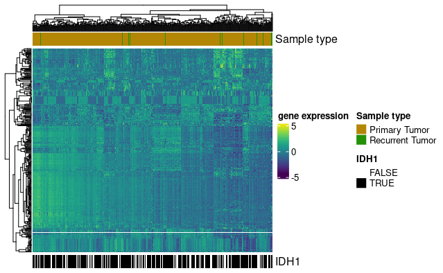

```r
ht3
```

# Project

For your project your goal is to describe the selected TCGA cohort:

- demographics (age, gender, and so on) - who were the patients whose data was analysed?
- survival data - what is the survival of this cancer?
- what are the subtypes identified in the analyses?
- somatic mutations - what are the most frequently mutated genes? what are the common mutations?
- gene expression - are there clearly visible patterns in gene expression? How does the expression of the highly mutated genes look like?

Create a blogpost with description of your analysis, document your progress. Try to add interactivity to your visualizations.

You will have to present the data to the rest of the hackathon groups at the end of this event. Prepare 10 minutes of showcasing the data, your visualizations.

This is the main project of this hackathon. From now on you will be working with your teams on your own and I will be available to guide you, answer your questions. You are expected to spend few hours each day working on this.

Good luck! I’m already excited to see your data viz!